# XAI_DecisionFactory: A Semi-Global XAI Framework for Actionable Insights

> *From black-box models to business-ready actions.*

## What is XAI_DecisionFactory?

**XAI_DecisionFactory** is an Explainable AI (XAI) framework designed to help data scientists, ML engineers, and business analysts **understand what their models have learned and translate that knowledge into actionable recommendations**. It combines data-driven results and statistics with the power of LLMs and Agentic AI.

This framework was developed from hands-on experience in data science and business analytics, with a strong focus on practical application It could be not exhaustive, opinionated, and deliberately practical — but here the goal is not perfection. The goal is to **inspire a different way of thinking** about model explainability empowered by Agentic AI also.

If you want to explore or run it yourself, the project is available on GitHub: **[XAI_DecisionFactory on GitHub](https://github.com/XAIFactory/XAI_DecisionFactory.git)**

## What This Doc Covers

1. **Semi-Global Explainability** — the idea behind the framework
2. **Framework Architecture** — a walkthrough of the three-phase pipeline
3. **Input Requirements** — what you need to run it, with concrete examples
4. **Application** — an example in **demo** industry context
5. **Results & Conclusions** — what the framework produces and where it can go next

## The Semi-Global Explainability

Machine learning models are powerful — but predictions alone don't make decisions. **People do.** And people need to understand *why* before they act.

**XAI_DecisionFactory** bridges that gap. It transforms predictive models — classification or regression — from opaque technical artifacts into tools that non-technical stakeholders can **interpret, trust, and act upon**. It makes insights **decision-ready**, not just technically accurate.

Most XAI techniques operate at two extremes:

- **Local explanations** (e.g., LIME, SHAP) focus on individual predictions — useful for debugging, but difficult to scale into decisions
- **Global explanations** (e.g., aggregated SHAP summaries) describe overall model behavior — informative, but often too abstract

**XAI_DecisionFactory operates in the middle** through a **semi-global explainability approach**.

Instead of explaining single predictions or the entire model, it identifies **statistically robust segments of observations** that share similar characteristics and predictive behavior.

This enables explanations that are:

- **Generalizable** based on data and objectives
- **Interpretable** based on explainable models output
- **Actionable** based on agent AI that understand the scope and suggest actions

## Why This is Interesting

- Moves beyond traditional SHAP/LIME toward **segment-level decision intelligence**
- Translates model outputs into **business-relevant narratives**
- Reduces the gap between **data science and decision-making**
- Automates the generation of **actionable insights and reports**
- Profiles can be dynamically assigned through data-driven rules

## Architecture: 3-Phase Pipeline

XAI_DecisionFactory combines **statistical modeling** with **agentic AI components (LLM-based agents)** to produce **interpretable and actionable insights**.

## Phase 1: Analytical Profiling

This phase transforms raw model outputs into **structured, interpretable profiles** in order to extracting statistically grounded insights.

**High-propensity (HP) observations** are defined as the top *x%* of model scores (threshold configurable). The objective is to identify **subpopulations with distinct behavioral and predictive patterns**.

### Methodological Steps

- **Input** Dataset with model scores for each row ID. In the Python implementation, the score should be numeric (e.g., the predicted probability of class 1 or regression values), along with the row ID representing the unit of analysis, and the top 20 most important features used for model training, as too many features make human interpretability difficult (assuming the model is well-trained, performs adequately, and generalizes well)
- **SHAP-based Modeling** Train a secondary model (Random Forest or LightGBM) using HP as the target to compute SHAP values
- **Dimensionality Reduction (PCA)** Reduce feature space complexity while preserving variance. The input data are features+HP target (not the shap values), this approach finds better fit with the expected output of the framework.
- **Clustering (DBSCAN)** Identify dense groups of similar observations using PCA factors. Retain only clusters with significantly higher HP rates than baseline. DBSCAN does't require number of clusters as parameters but it can gound by itself the "best" number of cluster.
- **Decision Tree Profiling** Extract interpretable rules describing each cluster. Retain only leaves with significantly higher HP rates than baseline. These final leaves are called *profiles*
- **Logistic Regression (Odds Ratios)** Quantify feature contributions within each profile

This hybrid approach ensures both robustness and interpretability.

### Outputs

- Profile-level statistical summaries
- Global feature impact via SHAP values
- Interpretable rules
- Feature importance and Odds Ratios
- Structured `.csv` / `.json` datasets
- Profile assignment per observation
- PDF report with plots

You can analyze these data and outputs and extract actionable insights autonomously across the profiles without necessarily relying on agentic AI. However, if you have access to highly capable LLMs with strong abstract thinking and analytical reasoning, I recommend experimenting with agentic AI approaches.

## Phase 2: Agentic AI-Context Understanding

An LLM-based agent for structuring context knowledge It ingests:

- Business domain and objectives
- Model purpose
- Feature definitions
- Constraints and success criteria

It produces a **formalized contextual representation**, aligning technical outputs with business meaning.

## Phase 3: Agentic AI-Analytical Reasoning

An LLM-based agent that bridges statistics and decision-making. This agent combines:

- Context (Phase 2)
- Statistical profiles (Phase 1)

It generates:

- Human-readable profile descriptions
- Data-grounded explanations
- Targeted recommendations

Each profile becomes a **decision unit**.

Here the workflow of the framework

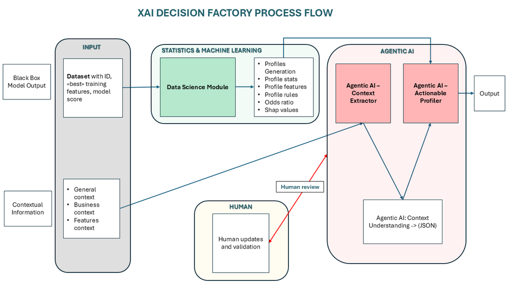

*Figure1: Framework Workflow*

## LLM Implementation

- For this conceptual exercise I've used **phi3-mini via Ollama**
- Runs efficiently on a basic CPU — no GPU required
- Easily generalizable to other Ollama-compatible LLMs, including different models per agent scope
- For more demanding deployments, the architecture supports integration with more powerful Ollama LLMs depending on your infrastructure

## Input Requirements

### Phase 1: Analytical Profiling

This phase assumes the model you want to interpret is **already well-trained and generalizes well**. The framework does not validate your predictive model — it interprets it.

Provide a dataset containing:

- **Unique ID** — one row per observation
- **Model score** — the output of your predictive model
- **Top ~20 relevant features** — the most important/informative variables driving the score

> Keep the feature set focused: too many features reduce interpretability. Make sure to **encode ordinal features** before running the framework. The python process only manages categorical and numerical features

### Phase 2: Context Understanding

The first agent receives structured business knowledge via three CSV files:

| File | Purpose |
| --- | --- |
| `features_context.csv` | Feature list with descriptions and human-readable concepts associated with each variable |
| `biz_context.csv` | Business context: agent role, objectives, target audience, constraints, and success criteria |
| `general_context.csv` | General framework configuration |

By providing this context, the agent understands **what we want to do with the model outputs** — grounding the analysis in real business meaning before any analytical reasoning takes place.

> **Note:** only modify `features_context.csv` and `biz_context.csv` to match your use case. Leave `general_context.csv` unchanged.

### Phase 3: Analytical Reasoning

This agent bridges statistics and strategy. It takes as input:

- The **structured context** produced by the Phase 2 agent
- The **statistical profiles** generated in Phase 1 (rules, SHAP importance, odds ratios, profiles and related statistics)

By combining these two layers, the agent translates raw ML outputs into **human-readable profile descriptions**, **data-grounded explanations**, and **specific, actionable business recommendations** — always aligned with the objectives and constraints defined in the business context.

Each profile becomes a **decision unit**: a self-contained narrative that a business team can read, validate, and act upon directly.

## Business Case: From Predictions to Strategy in Electric Mobility

Let's do an excerise together:

Consider a **B2C retailer in the electric mobility sector**.

The company has launched a new electric scooter and built a **propensity-to-purchase model** to identify likely buyers.

However, predictions alone are not sufficient. The business needs to answer:

- Who are these high-propensity customers?
- What defines them behaviorally?
- How should we engage them?

This is where **XAI_DecisionFactory** provides value.

Instead of isolated predictions, it identifies **coherent customer segments**, explains their behavior, and suggests **targeted actions**.

Here the features context:

| Feature | Description | Concept |
| --- | --- | --- |
| `IDCLI` | Raw ID – unique client identifier | — |
| `Professione` | Client job | Socio-Demographic |
| `Capacita_d_spsa` | Client purchasing power | Socio-Demographic |
| `LTV` | Customer lifetime value | Loyalty |
| `RFM_Score` | Recency, Frequency, Monetary score – higher values indicate more frequent purchases and higher spending | Loyalty & Purchase Behavior |
| `Numero_Prodotti_Acquistati_12m` | Number of products purchased in the last 12 months | Purchase Behavior |
| `Eta` | Client age | Socio-Demographic |
| `Tenure` | Relationship duration with the company (years) | Socio-Demographic |
| `LivelloDigitalizzazione` | Client digital literacy level | Digital Literacy |
| `GrandCentr` | Equals 1 if the client lives in a large city | Socio-Demographic |
| `Engagement` | Measure of client engagement with the company (CRM interactions, app usage) | Loyalty |
| `LifeCycle` | Client life cycle stage (private life stage) | Personal Life Cycle |
| `margins12months` | Margins generated by the client in the last 12 months | Purchase Behavior |
| `GreenSurveyScore` | Score measuring client sensitivity to environmental/green topics | Green Sensitivity |
| `ultimoPDTAcquistato` | Last purchased product | Purchase Behavior |
| `PDTCategTotalSpending` | Product category where the client spent the most in the last 12 months | Purchase Behavior |
| `score` | Machine learning model score | ML Model Score |

Here the business context:

| Parameter | Value |
| --- | --- |
| `Role` | Act as an expert in Explainable AI (XAI), data science, behavioral psychology, and marketing & sales strategy. |
| `ML Scope` | Evaluate and quantify the propensity of a customer to purchase a next-generation electric scooter. |
| `Industry` | E-Mobility — Retail — B2C |
| `Business Unit` | Marketing & Sales |
| `Business Scope` | Develop and optimize a personalized sales and marketing strategy for electric scooters, targeting customer segments with high purchase propensity as identified by a custom XAI-enabled machine learning… |
| `Output Format` | JSON — clear and logical structure suitable for downstream automation. Use the information provided by general context, features context, and business context. |
| `Additional Instructions` | Keep all provided information in memory. Include copy ideas for the marketing team. |

## Applying the Framework

### Step 1: Analytical Profiling

**Input:**

- Customer features
- Model scores

```
ds_profile_generator(
    work_directory="XAI_DecisionFactory",  # Root project directory
    file_path="XDF_abt_input/ActionForge.csv",  # Input dataset (CSV format)
    sep=";",                                     # CSV column separator
    decimal=",",                                 # Decimal separator
    id_col="IDCLI",                              # Unique identifier column
    target_score_col="score",                    # Model score column
    threshold=10,                                # Top 10% = High Propensity
    min_profile_size=0.06,                       # Minimum profile size (% of total population)
    eps=0.25,                                     # DBSCAN neighborhood radius
    output_path="XDF_analytical_output"          # Output folder
)
```

```
PIPELINE COMPLETED SUCCESSFULLY
PROFILES GENERATED: 3
  -> Outputs saved in: XDF_analytical_output/
```

**Parameters:**

| Parameter | Description |
| --- | --- |
| `work_directory` | Root project directory |
| `file_path` | Input dataset path (CSV format) |
| `sep` | CSV column separator |
| `decimal` | Decimal separator |
| `id_col` | Unique identifier column |
| `target_score_col` | Model score column |
| `threshold` | Percentile threshold for HP definition (e.g., `10` = top 10% marked as High Propensity) |
| `min_profile_size` | Minimum profile size as % of total population |
| `eps` | DBSCAN neighborhood radius (clustering parameter) |
| `output_path` | Output directory |

**Process:**

- SHAP Analysis — feature importance and contribution evaluation using SHAP values to interpret model predictions at global level.
- PCA + Clustering — dimensionality reduction via Principal Component Analysis followed by density-based clustering (DBSCAN) to identify natural groupings within the data. Clustering is based on original features (not shap values) + HP (High propensity information) -> (features space + propensity space).
- Cluster Statistical Validation — assessment of cluster propensity through z-test and p-value analysis, verifying whether the proportion of high propensity cases (HP = 1) within each cluster is statistically significantly higher than in the overall population.
- Rule Extraction & Profile Definition — derivation of interpretable decision rules from each cluster using a Decision Tree, enabling the construction of actionable behavioral profiles.
- Profile Statistical Validation — confirmation of profile propensity via z-test and p-value analysis, ensuring that the proportion of HP = 1 within each profile is statistically significantly higher than the baseline population rate.

**Output:**

- Interpretable profiles
- Behavioral rules
- Measurable uplift

Profiles show different propensity:

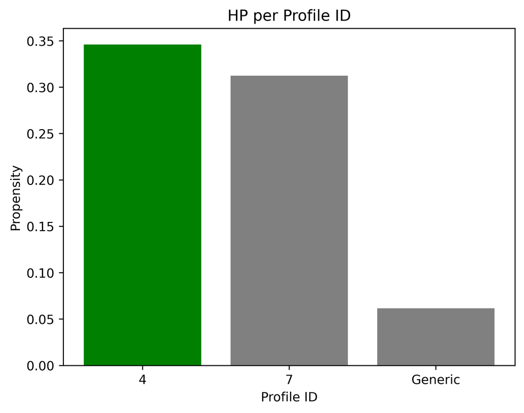

*Figure2: Propensity by Profile*

**Global SHAP — Feature Importance** Before diving into individual profiles, it is always good practice to inspect **global explainability** as a sanity check — ensuring that the semi-global layer remains coherent with the overall model behavior.

The SHAP summary chart highlights the three most impactful features driving High Propensity:

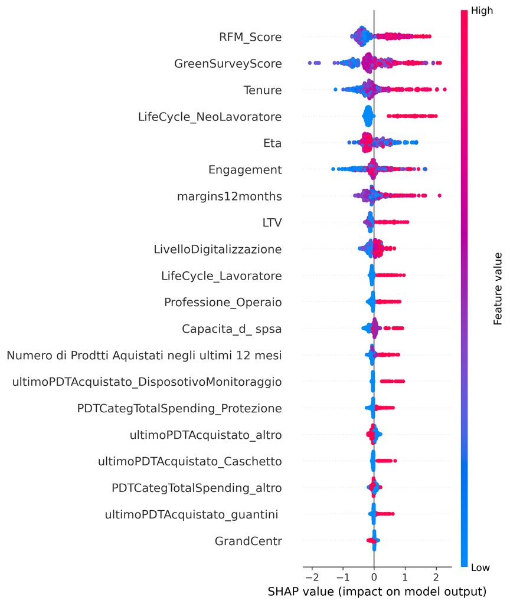

*Figure3: SHAP Gobal Impact on HP*

- **RFM Score** — higher values are associated with higher propensity
- **GreenSurveyScore** — stronger environmental sensitivity correlates with higher propensity
- **Tenure** — longer customer relationships are associated with higher propensity

These global signals set the interpretive foundation for everything that follows at the profile level.

**PCA — 2D Projection of Generated Profiles**

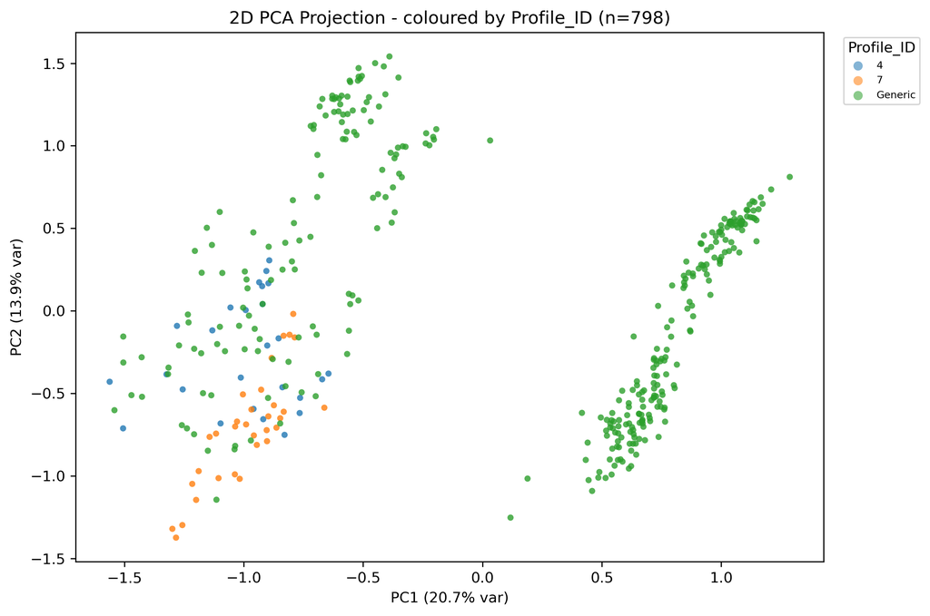

*Figure 4: Profiles in 2D*

Second, two principal components alone are not sufficient to fully represent the complexity of the feature space. Some overlap between profiles is expected in 2D: the patterns that truly differentiate segments live in higher dimensions, and this projection is necessarily a simplification — a useful visual aid, not a complete picture.

**Profiles STATS**

| Profile_ID | Cap_d_spsa | LTV | RFMScore | Eta | Tenure | DgitialScore | GrandCentr | Engagement | GreenSurveyScore | score | HP | n_cli | LifeCycle |
| --- | --- | --- | --- | --- | --- | --- | --- | --- | --- | --- | --- | --- | --- |
| 4 | 2.23 | 2.35 | 6.23 | 26.42 | 7.19 | 3.12 | 0.42 | 0.72 | 8.33 | 0.69 | 0.35 | 52 | ALTRO |
| 7 | 2.84 | 2.69 | 6.94 | 40.25 | 9.97 | 3.53 | 0.34 | 0.75 | 7.86 | 0.68 | 0.31 | 64 | NeoLavoratore |
| Generic | 1.89 | 1.70 | 3.77 | 53.40 | 5.39 | 2.40 | 0.28 | 0.58 | 7.21 | 0.44 | 0.06 | 682 | ALTRO |

The table above summarizes the key statistics for each identified profile.

Profiles **4** and **7** both show significantly higher propensity scores compared to the **Generic** segment, confirming that the framework successfully isolates behaviorally distinct, high-value customer groups.

Key differentiating factors for this profile include:

- **GrandCentr** are higher than all other profiles, indicating a customer who lives in urban context.
- **GreenSurveyScore** is the highest across all profiles, pointing to a strong sensitivity toward environmental and sustainability topics — a key psychological lever for electric mobility messaging
- **Age** on average is lower than other profiles

Data Insights Professional using all these information can deign beatufiul data story for drive business decision. But if the have powerful LLms at tehir disposal they can use the next 2 gentic steps to get inspired In this context I'll tun phi-3mini just for tool guide example, better models can lead better results

### Step 2: Context Understanding

Let's feed our first agent with all the contextual informations and business scenario.

**Input:**

- Business objectives
- Domain knowledge
- Feature meanings

```
# ---------------------------------------------------------
# STEP 2: Context ingestion agent
# Loads business, general and feature-level context
# to enrich the interpretation layer
# ---------------------------------------------------------
res2 = execute_agent_context(
        work_directory="XAI_DecisionFactory_GitHub",     #work directory where the folder containing the "main_modules" folder is stored
        general_csv="XDF_context_infos/general_context.csv",   # General contextual information
        business_csv="XDF_context_infos/biz_context.csv",      # Business context and domain knowledge
        features_csv="XDF_context_infos/features_context.csv",  # Feature descriptions and human-readable meanings
        ollama_url = "http://localhost:11434/api/chat", #it's standard host of local ollama (change just if required)
        llm = "phi3:mini" #ollama local installed model (eg if you have mistral and GPU you can use it)
    )
```

**Parameters:**

| Parameter | Description |
| --- | --- |
| `general_csv` | General domain context |
| `business_csv` | Business objectives and constraints |
| `ollama_url` | ollama_url, if your model run in local just leave the default values |
| `llm` | OLLAMA LLM you want to use (need to be installed and up and running on your machine) |

Let's run:

```
Model: phi3:mini

 Reading CSV...
 Sendig Context to llm...


────────────────────────────────────────────────────────────
 AGENT CONTEXT EXTRACTION:

Agent Role: Expert in Explainable AI (XAI) with a focus on data science for behavioral analysis within the electric scooter marketing strategy development scope. The agent's role is to interpret model outputs, ensuring they are accurate and actionable insights that align with business objectives while maintaining transparency in how decisions can be traced back to specific signals from the data.

General Context:
- Domain: Electric Scooter Retail (B2C) market within E-Mobility industry, targeting customer segments for personalized sales and marketing strategies based on their propensity to purchase next-generation electric scooters.
- Environmental Dynamics: The agent operates in a highly competitive retail sector where understanding consumer behavior is crucial. Key actors include customers (potential buyers), the company as both seller and marketer, and other stakeholders interested in driving sales conversions. Constraints may involve budget limitations, marketing channel effectiveness, and rapid execution of strategies to capitalize on identified high-impact decisions.

Business Context:
Key Objectives:
- Increase electric scooter sales conversion rates among targeted customer segments with a propensity for purchase (as indicated by the ML model).
- Maximize revenue uplift through personalized and actionable marketing strategies tailored to high-impact decision profiles.
Strategic Priorities:
- Identify distinctive customer behaviors using machine learning insights from provided data, focusing on purchase behavior, digital engagement levels, sensitivity to green topics (environmental concerns), loyalty scores, and lifetime value indicators such as RFM score Recency, Frequency, Monetary.
Operational Drivers:
- Align marketing efforts with customer profiles that exhibit high responsiveness to action-oriented stimuli based on the ML model's internal weightings (e.g., frequency of purchases and engagement levels).
KPIs/Business Logic Relevant to Scenario:
- Customer purchase behavior within specific product categories over time, digital channel preferences indicating higher sensitivity or interaction with green topics, loyalty score as an indicator of potential for future sales growth.
Strategic Priorities and Operational Drivers Identified from Features Context (to be analyzed by the agent):
- IDCLI: Unique identifier linking to customer demographics such as profession without direct impact on purchase decisions but may provide insights into lifestyle or socioeconomic status.
- Professione, Capacita_d_spsa (Purchasing Power), etc.: Socio-demographic variables that could correlate with purchasing behavior and preferences for eco-friendly products like electric scooters.
- RFM Score: Reflecting customer loyalty based on recency of purchase, frequency, and monetary value generated by the client; used to segment customers likely interested in new offerings (e.g., next-generation models).
- Engagement: A measure of how engaged a customer is with past interactions or marketing efforts through CRM channels and app usage, which could indicate openness to future purchases if positively aligned with the brand's messaging on sustainability and technology advancements.
- LTV (Customer Life Value): Indicates potential revenue from long-term customer relationships; high lifetime value customers may be more willing or able to invest in new, innovative products like electric scooters.
- GreenSurveyScore: Represents the sensitivity of a client towards environmental topics which could influence their likelihood to purchase eco-friendly transport options such

────────────────────────────────────────────────────────────

Enter feedback to refine, or 'yes' to confirm:

You ->  yes
[OK] Confirmed.
saving output in: context_memory.json
```

**Output:**

- Structured contextual layer
- Note that you can refine agent output with human inputs or writing "yes" for accepting the results

for the specific scope I'd say that the context understood by the Agentic AI it's ok.

### Step 3: Analytical Reasoning

Let's generate acionable insight on our profiles using the second agent. Let's focus just on profile 4 for example:

**Input:**

- Profiles (Phase 1)
- Context (Phase 2)

```
# ---------------------------------------------------------
# STEP 3: Profile interpretation agent
# Combines analytical outputs with context to generate
# explainable and actionable insights at profile level
# ---------------------------------------------------------
res3 =
    run_profile_agent(
        work_directory       = "XAI_DecisionFactory_GitHub",
        oddratio_csv         = "XDF_analytical_output/oddsratio.csv",
        profile_features_csv = "XDF_analytical_output/profile_features.csv",
        profile_stats_csv    = "XDF_analytical_output/profile_stats.csv",
        profile_rules_csv    = "XDF_analytical_output/profile_rules.csv",
        shap_importance_json = "XDF_analytical_output/shap_importance.json",
        context_memory       = "context_memory.json",
        sep                  = ",", # CSV separator
        llm                  = "phi3:mini",
        ollama_url           = "http://localhost:11434/api/chat"
    )
```

**Parameters:**

| Parameter | Description |
| --- | --- |
| `oddratio_csv` | Logistic regression odds ratio outputs |
| `profile_features_csv` | Decision tree feature importance per profile |
| `profile_stats_csv` | Aggregated statistics per profile |
| `profile_rules_csv` | Decision tree rules per profile |
| `shap_importance_json` | Global SHAP feature importance |
| `context_memory` | Structured context generated by the context agent |
| `llm` | OLLAMA Model you want to use |
| `ollama_url` | ollama_url, if your model run in local just leave the default values |

Let's analyze just one profile testing also the human feedback, for example:

```
============================================================
  PROFILE ANALYST AGENT — powered by Ollama
  Model : phi3:mini
============================================================

[INFO] Loading business context memory...
  [OK] Context memory loaded from 'context_memory.json'

[INFO] Loading profile CSV files...
  [OK] XDF_analytical_output/oddsratio.csv — 3 rows, 37 cols
  [OK] XDF_analytical_output/profile_features.csv — 6 rows, 2 cols
  [OK] XDF_analytical_output/profile_stats.csv — 3 rows, 24 cols
  [OK] XDF_analytical_output/profile_rules.csv — 7 rows, 3 cols

[INFO] Loading SHAP importance JSON...
  [OK] XDF_analytical_output/shap_importance.json — SHAP data loaded.
  [OK] Profile column: 'Profile_ID' — 3 unique profiles
Total Profiles to analyze: 3

============================================================
  PROFILE 1 of 3: '4'
============================================================

  [INFO] Analyzing profile: '4'...

────────────────────────────────────────────────────────────
## Profile Name and Tagline and Propensity Score | ID: 4
- **Name**: The Green Advocate Professional Employees (GAYPE)
- **Tagline**: Highly engaged, environmentally conscious professionals with a strong loyalty to the brand.
- **Propensity Score**: HP = 0.3461538461538461 -> This indicates that while they have high purchase intentions (HP), their overall propensity score is lower, suggesting caution in conversion strategies should be taken to ensure alignment with the brand's sustainability messaging and customer expectations.

### Who Are They? (Storytelling)
The Green Advocate Professional Employees are individuals who spend an average of 2.346153846 times per month on electric scooters, visiting the brand's digital channels or making purchases with a frequency that reflects their dedication to sustainable transport options (Engagement = 0.7180173147692308). They are likely influenced by environmental topics and have shown sensitivity towards green initiatives, as indicated by the GreenSurveyScore of 8.327705800115384 (much higher than any other score in their profile), suggesting that they value eco-friendly transportation choices highly. Their lifetime value is significant at an average LTV of 2.346153846 times, and with a RFM_Score indicating frequent purchases within the last year (6.230769230769231), they are loyal customers who have spent on average $440 over the past 12 months in margins related to electric scooter accessories, with a notable interest shown towards products like gloves and helmets (profile_volume = 52.0).

The main difference between Profile ID: 4 customers versus other profiles is their exceptionally high GreenSurveyScore combined with strong loyalty scores; they are not only interested in the environmental impact of transportation but also demonstrate a consistent pattern of purchasing behavior and brand engagement, making them ideal targets for personalized marketing efforts.

### Key Data Insights
- **GreenSurveyScore** = 8.327705800115384 -> This means they are highly likely to be influenced by green initiatives and may respond well to sustainability messaging, differentiating them from other profiles with lower scores in this area (difference: significantly higher GreenSurveyScore).
- **RFM_Score** = 6.230769230769231 -> This indicates they are loyal customers who frequently engage and spend within the brand, suggesting a high lifetime value compared to others with lower scores (difference: higher RFM Score).

### Actionable Recommendations
- **Launch** an email marketing campaign focused on sustainability initiatives of electric scooter brands. Highlight eco-friendly transport options and the environmental impact, using personalized content that resonates with their high GreenSurveyScore to increase engagement and conversion rates among this group (justified by Engagement = 0.7180173147692308).

### Watch Out For
- **Risks or Pitfalls**: Overemphasis on sustainability messaging could alienate customers who are environmentally conscious but not as invested in green topics, potentially leading to a decrease in engagement and sales among this group (d

────────────────────────────────────────────────────────────

Enter feedback to refine, or 'yes' to confirm:

You ->  Key differentiating factors for this profile include: GrandCentr are higher than all other profiles, indicating   a customer who lives in urban context. GreenSurveyScore is the highest across all profiles, pointing to a strong sensitivity   toward environmental and sustainability topics — a key psychological lever for electric mobility messaging - Age on average is lower than other profiles, they have the highest propensity

[INFO] Updating response...
────────────────────────────────────────────────────────────

## Profile Name and Tagline and Propensity Score | ID: 4
- **Name**: Urban Green Advocates (UGA)
- **Tagline**: Young professionals with a strong environmental conscience living in urban areas.
- **Propensity Score**: GrandCentr = 0.4230769230769231 -> This suggests that they are more likely to be city dwellers who prioritize sustainability, differentiating them from other profiles with lower scores in this area (difference: higher urban-centric score).

### Who Are They? (Storytelling)
Urban Green Advocates represent a segment of young professionals within the electric scooter market who are deeply engaged and environmentally conscious. With an average age that is lower than other profiles, they have shown to be more receptive to green initiatives, as evidenced by their highest sensitivity towards environmental topics (GreenSurveyScore = 8.327705800115384). Their lifetime value and engagement with the brand are significant indicators of potential loyalty and advocacy for sustainable transport options in urban settings, where they spend time due to their proximity to city centers (LTV = 2.346153846 times higher than average LTV across all profiles).

The main differentiating factors between Profile ID: 4 customers and other segments are the combination of high GreenSurveyScores, indicating a strong environmental consciousness that aligns with urban living (GrandCentr = highest among all), suggesting they prioritize eco-friendly transportation choices. Their age demographic is also distinctive; being younger on average compared to other profiles suggests they are more adaptable and open to new technologies like electric scooters, which can be a key psychological lever for marketing strategies targeted at urban professionals seeking sustainable mobility solutions in city environments.

### Key Data Insights
- **GreenSurveyScore** = 8.327705800115384 -> This means they are highly likely to be influenced by green initiatives, differentiating them from other profiles with lower scores (difference: significantly higher GreenSurveyScore).
- **GrandCentr** = Higher than all other profiles, indicating a customer who lives in urban context and prioritizes sustainability -> This suggests they are more likely to be city dwellers seeking eco-friendly transportation options.
- **Age demographic is younger on average compared to other profiles**: Difference - Younger age group may indicate adaptability and openness towards new technologies like electric scooters, which can align with sustainable urban living (difference in Age).

### Actionable Recommendations
- **Increase** targeted social media campaigns on platforms popular among younger professionals. Use visual content that highlights the environmental benefits of using electric scooters and features real stories from within this demographic to showcase lifestyle integration with sustainability goals (justified by GreenSurveyScore = highest across all profiles).
- **Partner** with local urban businesses for co-promotions or pop-up events that offer discounts on electric scooters, leveraging the high engagement and loyalty of this group to drive word-of-mouth marketing (justified by LTV = significantly higher across all profiles).

### Watch Out For
- **Risks**: Younger demographics may have less disposable income or financial stability compared to older segments, potentially affecting their purchasing power. This could be a risk if not addressed with

────────────────────────────────────────────────────────────

Enter feedback to refine, or 'yes' to confirm:

You ->  yes
[OK] Confirmed.
[OK] Profile '4' confirmed — moving to next.

...
...
...

[OK] All profile descriptions saved to: profile_descriptions.json

[DONE] 3 profiles analyzed.
       Output: profile_descriptions.json
```

**Output:**

- Narrative descriptions for each profile
- Data-driven insights
- Actionable recommendations
- Note that also here you can refine agent output with human inputs or writing "yes" for accepting the results

Rember that phi3-mini is a "weak" llm model, just use it if you have basic CPU, for better outpout you can choose other models from ollama like mistral or phi4 or Llama3.

## Conclusion

This is a simplified example to demonstrate how the framework works. Refining results and improving profiles interpretation can lead to high-impact business discussions.

**XAI_DecisionFactory** provides a practical and scalable approach to explainability by focusing on **semi-global, segment-level insights**.

By combining:

- Statistical rigor
- Interpretable modeling
- Agentic AI with human-in-the-loop (Human validation and results checking)

it transforms machine learning models into **decision-support systems**.

The ultimate goal is to move from **model interpretability** to **decision intelligence**.

### **Future Improvements for the Frameworks**

- Integration of causal inference techniques to enhance model interpretability and support more reliable decision-making
- Adoption of more robust and scalable clustering validation strategies
- Development of a dedicated scoring phase, building on the initial function, to enable automated and consistent profile regeneration
- Domain-specific LLM fine-tuning to improve reasoning accuracy and contextual understanding
- Improved scalability and broader integration with more powerful LLMs, depending on the available infrastructure
- Additional software engineering enhancements to increase modularity, maintainability, and overall production readiness
- Implementation of an advanced Retrieval-Augmented Generation (RAG) pipeline

## Some References

[1] T. Yamaguchi, Y. Zhou, M. Ryo, K. Katsura, Agentic Explainable Artificial Intelligence (Agentic XAI) Approach To Explore Better Explanation (2025), arXiv:2512.21066

[2] D. Pedreschi, F. Giannotti, R. Guidotti, A. Monreale, L. Pappalardo, S. Ruggieri, F. Turini, Open the Black Box: Data-Driven Explanation of Black Box Decision Systems (2018), arXiv:1806.09936

Explore the project on GitHub and play with it: **[XAI_DecisionFactory on GitHub](https://github.com/XAIFactory/XAI_DecisionFactory.git)**

> *Luigi Esposito (XAIFactory)*